# coding_exercise_TCGA_infiltration

Benedek Danko

2024-02-02

```r
library("tidyverse")
library("ComplexHeatmap")
library("viridis")
```

# Coding exercise using TCGA immune infiltration data

Instructions are from coding_exercise_TCGA_infiltration.

First load the immune infiltration data:

```r
# CIBERSORT relative immune cell fractions:
tcga_immunfrac_cibersort <- read.table("data/TCGA.Kallisto.fullIDs.cibersort.relative.tsv",
                                       sep="\t", stringsAsFactors = F, header = T) %>%
  mutate(SampleID=str_replace_all(SampleID, "\\.", "-"),
         SampleID=str_extract(SampleID, "TCGA-[\\d\\w]{2}-[\\d\\w]{4}-[\\w\\d]{2}"))
# Estimated absolute leukocyte fractions:
tcga_all_leuk <- read.table("data/TCGA_all_leuk_estimate.masked.20170107.tsv",
                                       sep="\t", stringsAsFactors = F, header = F) %>%
  dplyr::rename("CancerType"="V1", "SampleID"="V2", "Fraction"="V3") %>%
  mutate(SampleID=str_extract(SampleID, "TCGA-[\\w\\d]{2}-[\\w\\d]{4}-[\\w\\d]{2}"))
# Downloaded mutational data for LUAD:
tcga_luad_mut <- read.table("/home/benedek_danko/R/coding_exercise_TCGA_infiltration/data/TCGA_LUAD_SNV_harmonized.txt",
                            header = T, sep="\t", stringsAsFactors = F,
                            quote="", fill=FALSE) %>%
  mutate(SampleID=str_extract(Tumor_Sample_Barcode, "TCGA-[\\w\\d]{2}-[\\w\\d]{4}-[\\w\\d]{2}"))
```

Check data:

```r
dim(tcga_immunfrac_cibersort)
```

```
## [1] 11373    27
```

```r
dim(tcga_all_leuk)
```

```
## [1] 10817     3
```

```r
str(tcga_immunfrac_cibersort)
```

```
## 'data.frame':    11373 obs. of  27 variables:
##  $ SampleID                    : chr  "TCGA-OR-A5JG-01" "TCGA-OR-A5LG-01" "TCGA-OR-A5JD-01" "TCGA-OR-A5LH-01" ...
##  $ CancerType                  : chr  "ACC" "ACC" "ACC" "ACC" ...
##  $ B.cells.naive               : num  0.00 7.17e-03 2.34e-05 4.73e-02 0.00 ...
##  $ B.cells.memory              : num  0.0485 0.0111 0.0146 0.0382 0.0248 ...
##  $ Plasma.cells                : num  0.01605 0.00798 0 0 0.00442 ...
##  $ T.cells.CD8                 : num  0.0461 0.1398 0.1049 0.1986 0.0515 ...
##  $ T.cells.CD4.naive           : num  0.027 0 0 0 0 ...
##  $ T.cells.CD4.memory.resting  : num  0.2907 0.1427 0.1749 0.0652 0.2259 ...
##  $ T.cells.CD4.memory.activated: num  0 0 0 0 0 ...
##  $ T.cells.follicular.helper   : num  0 0.00161 0.01793 0.04331 0 ...
##  $ T.cells.regulatory..Tregs.  : num  0 0 0 0 0 ...
##  $ T.cells.gamma.delta         : num  0 0 0 0 0 0 0 0 0 0 ...
##  $ NK.cells.resting            : num  0.02916 0.00791 0 0 0 ...
##  $ NK.cells.activated          : num  0.0432 0.0316 0.0703 0.1019 0.0325 ...
##  $ Monocytes                   : num  0.0467 0.0681 0.0861 0.1402 0.0993 ...
##  $ Macrophages.M0              : num  0 0 0 0 0 0 0 0 0 0 ...
##  $ Macrophages.M1              : num  7.19e-03 0.00 1.64e-03 1.21e-02 9.98e-05 ...
##  $ Macrophages.M2              : num  0.364 0.448 0.33 0.288 0.486 ...
##  $ Dendritic.cells.resting     : num  0.00271 0 0 0 0 ...
##  $ Dendritic.cells.activated   : num  0.026125 0.007464 0.00933 0.000576 0.042827 ...
##  $ Mast.cells.resting          : num  0.0328 0.1262 0 0 0 ...
##  $ Mast.cells.activated        : num  0 0 0.1907 0.0647 0.0174 ...
##  $ Eosinophils                 : num  0.0103 0 0 0 0.0148 ...
##  $ Neutrophils                 : num  0.00961 0 0 0 0 ...
##  $ P.value                     : num  0.112 0.104 0.068 0.388 0.246 ...
##  $ Correlation                 : num  0.0958 0.1033 0.1433 0.0288 0.0556 ...
##  $ RMSE                        : num  1.05 1.05 1.04 1.08 1.07 ...
```

```r
str(tcga_all_leuk)
```

```
## 'data.frame':    10817 obs. of  3 variables:
##  $ CancerType: chr  "ACC" "ACC" "ACC" "ACC" ...
##  $ SampleID  : chr  "TCGA-OR-A5J1-01" "TCGA-OR-A5J2-01" "TCGA-OR-A5J3-01" "TCGA-OR-A5J4-01" ...
##  $ Fraction  : num  0.0464 0.0579 0.0485 0.044 0.0168 ...
```

## Demonstrate that `TCGA.Kallisto.fullIDs.cibersort.relative.tsv` is relative immune cell abundance

```r
tcga_cibersort_rowsums <- rowSums(tcga_immunfrac_cibersort[, 3:24])
summary(tcga_cibersort_rowsums)
```

```
##    Min. 1st Qu.  Median    Mean 3rd Qu.    Max.
##       1       1       1       1       1       1
```

All cell tpye fractions sum up to 1 per sample, meaning that they are relative fractions (CIBERSORT).

## Calculate the absolute immune infiltration by using the `Leukocyte Fraction` using `TCGA_all_leuk_estimate.masked.20170107.tsv`

```r
# Calculate samples with more than 1 replicate:
tcga_replicate_samples <- tcga_immunfrac_cibersort %>%
  group_by(SampleID) %>%
  summarize(count=n()) %>%
  filter(count > 1) %>%
  arrange(desc(count))
nrow(tcga_replicate_samples)
```

```
## [1] 93
```

There are 93 samples with replicates. Let’s calculate mean fractions per sample for each cell type:

```r
tcga_immunfrac_cibersort_clean <- tcga_immunfrac_cibersort %>%
  group_by(SampleID) %>%
  summarise(across(
    starts_with("B.cells.naive"):ends_with("Neutrophils"),
    mean
  ))

tcga_all_leuk_clean <- tcga_all_leuk %>%
  dplyr::group_by(SampleID) %>%
  summarize(Fraction=mean(Fraction))
```

Calculate absolute fractions:

```r
# Intersect of the samples from the two tables:
intersect_samples <- intersect(tcga_immunfrac_cibersort_clean$SampleID,
                               tcga_all_leuk_clean$SampleID)
# Calculate absolute fractions:
tcga_abs_leuk_fractions <- tcga_immunfrac_cibersort_clean %>%
  left_join(tcga_all_leuk_clean %>%
              dplyr::select(c(SampleID, Fraction)),
            by="SampleID") %>%
  filter(SampleID %in% intersect_samples) %>%
  filter(!is.na(Fraction)) %>%
  mutate(Fraction=ifelse(Fraction < 0, 0, Fraction)) %>%
  mutate(across(-c(SampleID, Fraction), ~ . * Fraction))
summary(rowSums(tcga_abs_leuk_fractions[,2:23]))
```

```
##    Min. 1st Qu.  Median    Mean 3rd Qu.    Max.
## 0.00000 0.08708 0.17155 0.20819 0.29596 0.96420
```

I set absolute fraction for values below 0 to 0. I also removed samples without absolute leukocyte measurements.

## Group similar immune cell types together and calculate the absolute immune infiltration for B_cells, T_cells, NK_cells, Monocytes, Macrophages, DCs, Mast, Eosinophils and Neutrophils

```r
tcga_abs_leuk_fractions_grouped <- tcga_abs_leuk_fractions %>%
  dplyr::select(-Fraction) %>%
  column_to_rownames("SampleID") %>%
  t() %>%
  as.data.frame() %>%
  rownames_to_column("CellType") %>%
  mutate(CellType=case_when(str_detect(CellType, "B.cells") ~ "B_cells",
                            str_detect(CellType, "T.cells") ~ "T_cells",
                            str_detect(CellType, "NK.cells") ~ "NK_cells",
                            str_detect(CellType, "Monocytes") ~ "Monocytes",
                            str_detect(CellType, "Macrophages") ~ "Macrophages",
                            str_detect(CellType, "Dendritic.cells") ~ "DCs",
                            str_detect(CellType, "Mast.cells") ~ "Mast_cells",
                            CellType %in% c("Eosinophils", "Neutrophils") ~ "Eosinophils_Neutrophils",
                            TRUE ~ CellType)) %>%
  group_by(CellType) %>%
  summarise(across(.cols = everything(), .fns = sum))
```

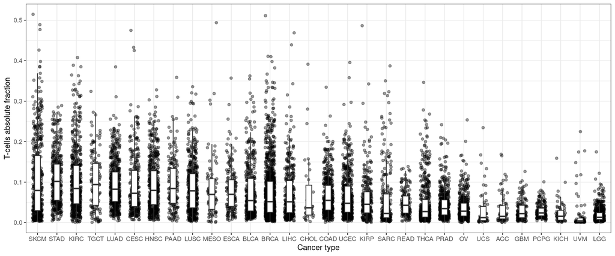

```r
# Format data for T-cells only, add cancer type info:
tcga_t_cells_per_cancertype <- tcga_abs_leuk_fractions_grouped %>%
  as.data.frame() %>%
  column_to_rownames("CellType") %>%
  t() %>%
  as.data.frame() %>%
  dplyr::select("T_cells") %>%
  rownames_to_column("SampleID") %>%
  left_join(tcga_immunfrac_cibersort %>%
              dplyr::select(c(SampleID, CancerType))) %>%
  group_by(CancerType) %>%
  mutate(mean_T=mean(T_cells)) %>%
  arrange(desc(mean_T))
tcga_t_cells_per_cancertype$CancerType <- factor(tcga_t_cells_per_cancertype$CancerType,
                                                 levels=unique(tcga_t_cells_per_cancertype$CancerType))

# Plot data:
ggplot(tcga_t_cells_per_cancertype,
       aes(x=CancerType, y=T_cells))+
  theme_bw()+
  geom_jitter(width = 0.25, alpha=.4)+
  geom_boxplot(outlier.shape = NA, width=.3, alpha=1)+
  xlab("Cancer type")+
  ylab("T-cells absolute fraction")
```

## Get the median level of immune infiltration of B_cells, T_cells, NK_cells, Monocytes, Macrophages, DCs, Mast and Eosinophils per cancer type and plot them in a heatmap

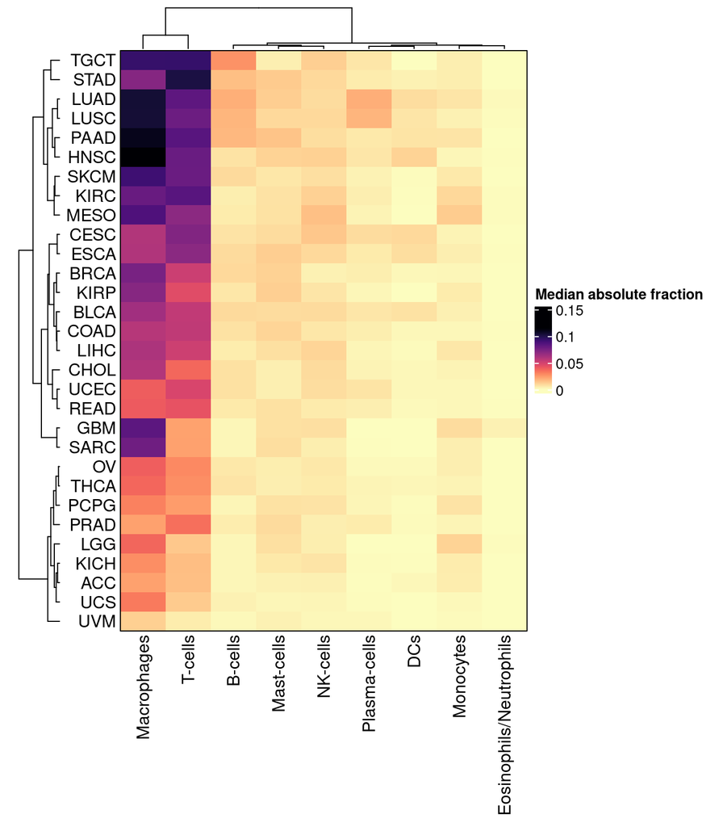

```r
# Format data, calculate mean fractions per cancer type:
tcga_main_cells_per_cancertype <- tcga_abs_leuk_fractions_grouped %>%
  as.data.frame() %>%
  column_to_rownames("CellType") %>%
  t() %>%
  as.data.frame() %>%
  rownames_to_column("SampleID") %>%
  left_join(tcga_immunfrac_cibersort %>%
              dplyr::select(c(SampleID, CancerType))) %>%
  dplyr::select(-SampleID) %>%
  group_by(CancerType) %>%
  summarise(across(.cols = everything(), .fns = median)) %>%
  as.data.frame() %>%
  column_to_rownames("CancerType")

# Plot:
colnames(tcga_main_cells_per_cancertype) <- c("B-cells", "DCs", "Eosinophils/Neutrophils",
                                              "Macrophages", "Mast-cells", "Monocytes",
                                              "NK-cells", "Plasma-cells", "T-cells")
Heatmap(tcga_main_cells_per_cancertype,
                         cluster_rows = T,
                         cluster_columns = T,
                         col = rev(viridis(n=100, option="magma")),
                         show_column_names = T,
                         name="Median absolute fraction",
                         border = TRUE,
                         show_row_names = T,
                         show_row_dend = T,
                         row_names_side = "left",
                         width=unit(100, "mm"))
```

## Plot the absolute infiltration level for B_cells, T_cells, NK_cells, Monocytes, Macrophages, DCs across different EGFR mutants for LUAD

Based on the LUAD masked mutational data downloaded using `TCGAbiolinks` and matched to our cell type abundance data, there are 28 Exon19 del., 17 Exon20 ins., 20 pL858R mut, 59 Other missense mut., and 472 WT cases.

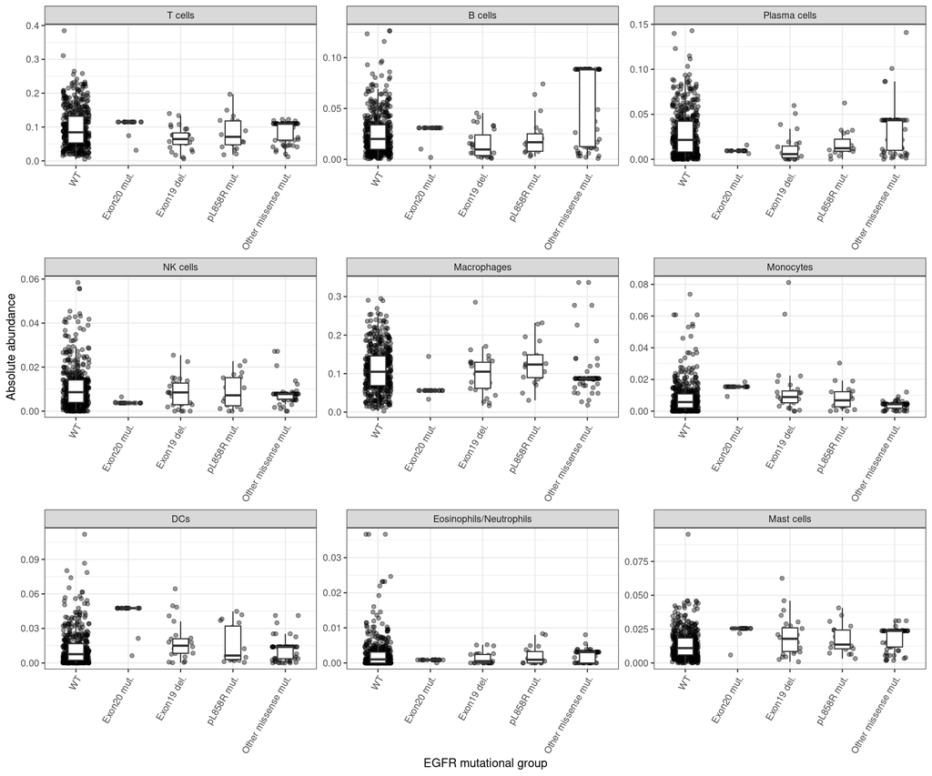

```r
# Get absolute fractions of main cell types for LUAD:
tcga_main_cells_luad <- tcga_abs_leuk_fractions_grouped %>%
  as.data.frame() %>%
  column_to_rownames("CellType") %>%
  t() %>%
  as.data.frame() %>%
  rownames_to_column("SampleID") %>%
  left_join(tcga_immunfrac_cibersort %>%
              dplyr::select(c(SampleID, CancerType))) %>%
  filter(CancerType=="LUAD") %>%
  dplyr::select(-CancerType)

# Get EGFR mutational data, create groups:
tcga_luad_egfr_mut <- tcga_luad_mut %>%
  filter(Hugo_Symbol=="EGFR") %>%
  mutate(group=case_when(Variant_Type=="INS" & Exon_Number=="20/28" ~ "exon20_ins",
                         Variant_Type=="DEL" & Exon_Number=="19/28" ~ "exon19_del",
                         HGVSp_Short == "p.L858R" ~"pL858R_mut",
                         TRUE ~ NA),
         group=ifelse(is.na(group) & Variant_Classification=="Missense_Mutation",
                      "other_missense_mut",
                      group)) %>%
  dplyr::select(c(SampleID, group))

# Merge the two data frames (we assume that samples without EGFR mutational data are WT):
tcga_main_cells_luad_groups <- tcga_main_cells_luad %>%
  left_join(tcga_luad_egfr_mut, by="SampleID") %>%
  mutate(group=ifelse(is.na(group), "WT", group)) %>%
  pivot_longer(-c(SampleID, group), names_to="CellType", values_to="Abs_abundance") %>%
  mutate(CellType=factor(CellType, levels=c("T_cells", "B_cells", "Plasma.cells","NK_cells",
                                            "Macrophages", "Monocytes","DCs", "Eosinophils_Neutrophils",
                                            "Mast_cells"),
                         labels=c("T cells", "B cells", "Plasma cells", "NK cells",
                                  "Macrophages", "Monocytes", "DCs", "Eosinophils/Neutrophils",
                                  "Mast cells")),
         group=factor(group, levels=c("WT", "exon20_ins", "exon19_del",
                                      "pL858R_mut", "other_missense_mut"),
                      labels=c("WT", "Exon20 mut.", "Exon19 del.",
                               "pL858R mut.", "Other missense mut.")))

# Plot data:
ggplot(tcga_main_cells_luad_groups,
       aes(x=group, y=Abs_abundance))+
  theme_bw()+
  theme(axis.text.x = element_text(angle=60, hjust = 1))+
  geom_jitter(width = 0.25, alpha=.4)+
  geom_boxplot(outlier.shape = NA, width=.3, alpha=1)+
  facet_wrap(vars(CellType), scales="free")+
  xlab("EGFR mutational group")+
  ylab("Absolute abundance")
```